# STAT 312R - HW2

Vinayak Mathur

23rd February 2022

1. Information on a packet of seeds claims that 42% of seed in the package produce large tomatoes, while 38% produce yellow tomatoes. Assume that size and color are independent. What’s the probability that a given seed will produce a large tomato or a yellow tomato?  
   ans) Let L be the event of getting a large tomato  
   Let Y be the event of a yellow tomato  
   P(L) = 0.42  
   P(Y) = 0.38  
   => P(L U Y) = P(L) + P(Y) - P(L n Y)  
   => P(L U Y) = 0.42 + 0.38 - 0.42*0.38

```r
print(0.42 + 0.38 - 0.42 * 0.38)
```

```
## [1] 0.6404
```

2. In a NiCd battery, a fully charged cell is composed of nickelic hydroxide. Nickel is an element that has multiple oxidation states. Assume the following proportions of the states:  
   Nickel Charge Proportions Found  
   0 0.17  
   +2 0.35  
   +3 0.33  
   +4 0.15
1. Determine the cumulative distribution function of the nickel charge.

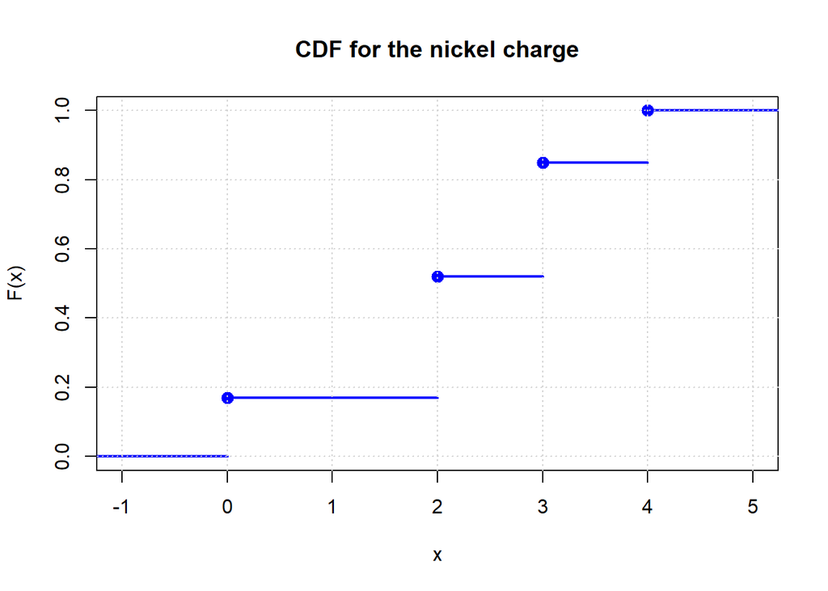

```r
nickelCharge <- c(0, 2, 3, 4)
proportionsFound <- c(0, 0.17, 0.35, 0.33, 0.15)

## Plotling CDF
plot(stepfun(nickelCharge, cumsum(proportionsFound)), vertical = F, pch = 20, cex = 2, lwd = 2, col = "blue", ylab = "F(x)",
     main = "CDF for the nickel charge")
grid()
```

2. Determine the mean and variance of the nickel charge.

```r
mean(nickelCharge)
```

```
## [1] 2.25
```

```r
sd(nickelCharge)^2
```

```
## [1] 2.916667
```

3. Heart failure is due to either natural occurrences (87%) or outside factors (13%). Outside factors are related to induced substances or foreign objects. Natural occurrences are caused by arterial blockage, disease, and infection. Suppose that 20 patients will visit an emergency room with heart failure. Assume that causes of heart failure for the individuals are independent.
1. What is the probability that three individuals have conditions caused by outside factors?

```r
p <- 0.13
ans1 <- dbinom(3, 20, p)
print(ans1)
```

```
## [1] 0.2347265
```

2. What is the probability that three or more individuals have conditions caused by outside factors?

```r
print(1 - dbinom(2, 20, p))
```

```
## [1] 0.7381896
```

3. What are the mean and standard deviation of the number of individuals with conditions caused by outside factors?

```r
res <- 20 * p
print(res)
```

```
## [1] 2.6
```

```r
print(sqrt(20 * 0.13 * 0.87))
```

```
## [1] 1.503995
```

6. The demand for water use in Phoenix in 2003 hit a high of about 442 million gallons per day on June 27 (http://phoenix.gov/WATER/wtrfacts.html). Water use in the sum- mer is normally distributed with a mean of 310 million gallons per day and a standard deviation of 45 million gallons per day. City reservoirs have a combined storage capacity of nearly 350 million gallons.
1. What is the probability that a day requires more water than is stored in city reservoirs?

```r
1 - pnorm(350, 310, 45)
```

```
## [1] 0.1870314
```

2. What reservoir capacity is needed so that the probability that it is exceeded is 1%?

```r
qnorm(0.99, 310, 45)
```

```
## [1] 414.6857
```

```r
qnorm(0.99, 310, 45)
```

```
## [1] 414.6857
```